# R4DS Learning Notes Part 1

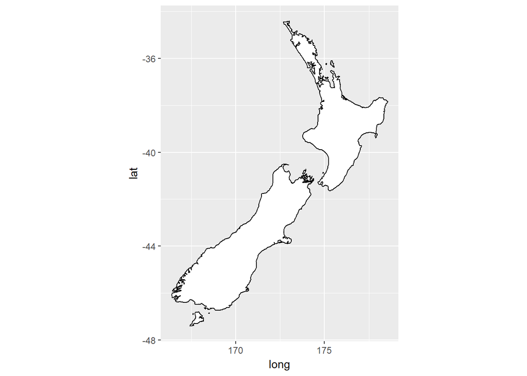

```r
ggplot(nz, aes(long, lat, group = group)) +
  geom_polygon(fill = "white", colour = "black") +
  coord_quickmap()
```

- `coord_polar()` uses polar coordinates. Polar coordinates reveal an interesting connection between a bar chart and a Coxcomb chart.

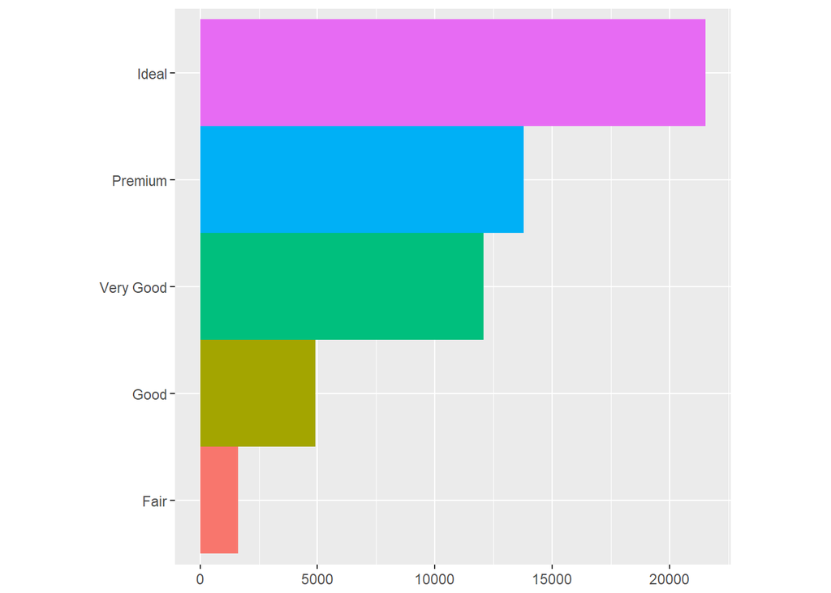

```r
bar <- ggplot(data = diamonds) +
  geom_bar(
    mapping = aes(x = cut, fill = cut),
    show.legend = FALSE,
    width = 1
  ) +
  theme(aspect.ratio = 1) +
  labs(x = NULL, y = NULL)
bar + coord_flip()
```

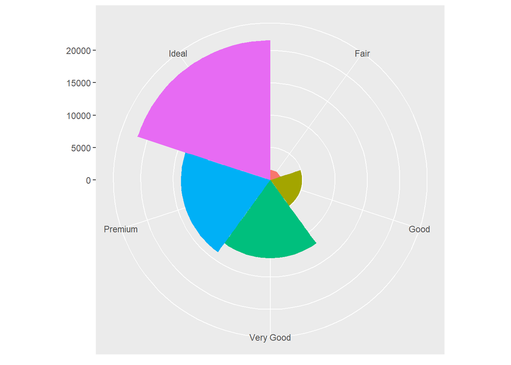

```r
bar + coord_polar()
```

Here shows how to draw a pie chart with `coord_polar()`, more ways to use `coord_polar()` could be found in this [link](http://ggplot2.tidyverse.org/reference/coord_polar.html)

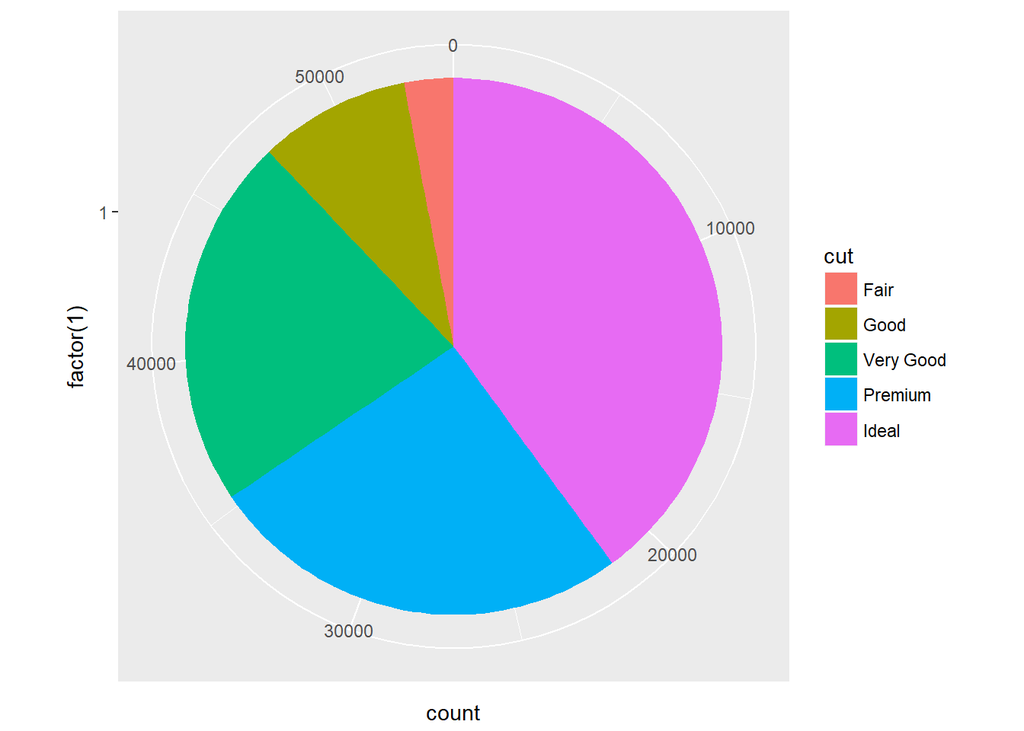

```r
ggplot(data = diamonds) +
  geom_bar(
    mapping = aes(x =factor(1), fill = cut),
    width = 1
  ) +
  coord_polar(theta="y")
```

### The Layered Grammar of Graphics

Now we learned much more than how to make scatterplots, bar charts, and boxplots. We learned a foundation that we can use to make any type of plot with ggplot2. To see this, let’s add position adjustments, stats, coordinate systems, and faceting to our code template:

```r
#ggplot(data = <DATA>) +
#  <GEOM_FUNCTION>(
#     mapping = aes(<MAPPINGS>),
#     stat = <STAT>,
#     position = <POSITION>
#  ) +
#  <COORDINATE_FUNCTION> +
#  <FACET_FUNCTION>
```

This is the first part of my learning notes for *R for Data Science*. Through this part of learning, I find many details that I didn’t notice when I used ggplot2 before. Just as a chinese old saying said, “Consider the past, and you shall know the future.”. It will be really helpful for me to review what I’ve learned before and try to find what I ignored before. And I will continue writing learning notes to record my study process. I also hope it could help someone who encounters problems about ggplot2 and want to find solutions through others’ blog, just like what I usually do.